# Assignment: Data Manipulation, EDA and Viz - Nomad Dataset (Example Solution)

Daniel S. Hain (dsh@business.aau.dk)

Updated September 18, 2020

# Preamble

## Standard packages

```r
### Load packages
library(tidyverse) # Collection of all the good stuff like dplyr, ggplot2 ect.
library(magrittr) # For extra-piping operators (eg. %<>%)
```

## Load data

Trips

```r
trips <- read_csv('https://sds-aau.github.io/SDS-master/M1/data/trips.csv')
```

```r
trips %>% glimpse()
```

```
Rows: 46,510
Columns: 11
$ X1           <dbl> 0, 1, 2, 3, 4, 5, 6, 7, 8, 9, 10, 11, 12, 13, 14, 15, 16, 17, 18, 19, 20, 21, 22, 23,…
$ username     <chr> "@lewellenmichael", "@lewellenmichael", "@lewellenmichael", "@lewellenmichael", "@way…
$ country      <chr> "Mexico", "Mexico", "Mexico", "Jordan", "China", "Vietnam", "Hong Kong", "China", "Ch…
$ country_code <chr> "MX", "MX", "MX", "JO", "CN", "VN", "HK", "CN", "CN", "CN", "TH", "MY", "KH", "VN", "…
$ country_slug <chr> "mexico", "mexico", "mexico", "jordan", "china", "vietnam", "hong-kong", "china", "ch…
$ date_end     <date> 2018-06-15, 2018-06-03, 2017-11-05, 2017-08-07, 2017-03-18, 2017-02-16, 2016-09-01, …
$ date_start   <date> 2018-06-04, 2018-05-31, 2017-11-01, 2017-07-24, 2017-02-17, 2016-09-02, 2016-08-02, …
$ latitude     <dbl> 21, 19, 21, 31, 40, 10, 22, 22, 22, 18, 7, 3, 11, 10, 13, 26, 27, 27, 28, 28, 19, 11,…
$ longitude    <dbl> -101, -99, -86, 35, 122, 106, 114, 114, 113, 109, 98, 101, 104, 106, 80, 75, 78, 78, …
$ place        <chr> "Guanajuato", "Mexico City", "Cancun", "Amman", "Yingkou", "Ho Chi Minh City", "Shenz…
$ place_slug   <chr> "mexico", "mexico-city-mexico", "cancun-mexico", "amman-jordan", "china", "ho-chi-min…
```

People

```r
people <- read_csv('https://sds-aau.github.io/SDS-master/M1/data/people.csv')
```

```r
people %>% glimpse
```

```
Rows: 4,016
Columns: 6
$ X1            <dbl> 0, 1, 2, 3, 4, 5, 6, 7, 8, 9, 10, 11, 12, 13, 14, 15, 16, 17, 18, 19, 20, 21, 22, 23…
$ username      <chr> "@lewellenmichael", "@waylandchin", "@karan", "@skaboss217", "@apwn", "@samcalma", "…
$ followers     <dbl> 1, 0, 2, 0, 17, 3, 4, 2, 17, 2, 11, 11, 5, 8, 0, 9, 3, 5, 25, 1, 1, 1, 61, 2, 11, 0,…
$ following     <dbl> 2, 2, 1, 1, 426, 3, 9, 3, 23, 2, 17, 6, 9, 7, 1, 6, 3, 34, 23, 4, 4, 4, 120, 2, 10, …
$ work_raw      <chr> "Software Dev, Startup Founder, Finance, Crypto, Product Manager, Education, Data, E…
$ education_raw <chr> "High School, Bachelor's Degree", NA, NA, NA, NA, NA, NA, "High School, Bachelor's D…
```

Countries

```r
countries <- read_csv( 'https://sds-aau.github.io/SDS-master/M1/data/countrylist.csv')
```

```r
countries %>% glimpse()
```

```
Rows: 249
Columns: 3
$ alpha_2    <chr> "AF", "AX", "AL", "DZ", "AS", "AD", "AO", "AI", "AQ", "AG", "AR", "AM", "AW", "AU", "AT…
$ region     <chr> "Asia", "Europe", "Europe", "Africa", "Oceania", "Europe", "Africa", "Americas", NA, "A…
$ sub_region <chr> "Southern Asia", "Northern Europe", "Southern Europe", "Northern Africa", "Polynesia", …
```

# 1: Preprocessing

## a. Trips: transform dates into timestamps

```r
trips %>% select(date_start, date_end) %>%
  glimpse()
```

```
Rows: 46,510
Columns: 2
$ date_start <date> 2018-06-04, 2018-05-31, 2017-11-01, 2017-07-24, 2017-02-17, 2016-09-02, 2016-08-02, 2…
$ date_end   <date> 2018-06-15, 2018-06-03, 2017-11-05, 2017-08-07, 2017-03-18, 2017-02-16, 2016-09-01, 2…
```

`readr` is smart, so if you loaded the data with `read_csv`, then this is already taken care of. Otherwise:

```r
# To demonstrate, I transform it back to a string.
trips %<>% mutate(date_start = date_start %>% as.character(),
                  date_end = date_end %>% as.character())
```

```r
trips %>% select(date_start, date_end) %>%
  glimpse()
```

```
Rows: 46,510
Columns: 2
$ date_start <chr> "2018-06-04", "2018-05-31", "2017-11-01", "2017-07-24", "2017-02-17", "2016-09-02", "2…
$ date_end   <chr> "2018-06-15", "2018-06-03", "2017-11-05", "2017-08-07", "2017-03-18", "2017-02-16", "2…
```

In case it is a string but well formated, we can use the `lubridate` packages.

```r
library(lubridate) # This is tidyverse's datetime package

trips %<>% mutate(date_start = date_start %>% as_date(),
                  date_end = date_end %>% as_date())
```

```r
trips %>% select(date_start, date_end) %>%
  glimpse()
```

```
Rows: 46,510
Columns: 2
$ date_start <date> 2018-06-04, 2018-05-31, 2017-11-01, 2017-07-24, 2017-02-17, 2016-09-02, 2016-08-02, 2…
$ date_end   <date> 2018-06-15, 2018-06-03, 2017-11-05, 2017-08-07, 2017-03-18, 2017-02-16, 2016-09-01, 2…
```

## b. Calculate trip duration in days

```r
trips %<>% mutate(trip_duration = date_end - date_start)
```

```r
trips %>%
  select(trip_duration, date_start, date_end) %>%
  head()
```

| trip_duration | date_start | date_end |
| --- | --- | --- |
| 11 days | 2018-06-04 | 2018-06-15 |
| 3 days | 2018-05-31 | 2018-06-03 |
| 4 days | 2017-11-01 | 2017-11-05 |
| 14 days | 2017-07-24 | 2017-08-07 |
| 29 days | 2017-02-17 | 2017-03-18 |
| 167 days | 2016-09-02 | 2017-02-16 |

Seems to work fine :)

## c. Filter extreme (fake?) observations for durations as well as dates - start and end

Lets inspect:

```r
trips %>%
  select(trip_duration, date_start, date_end) %>%
  summary()
```

```
 trip_duration       date_start            date_end
 Length:46510      Min.   :0003-11-12   Min.   :0012-07-12
 Class :difftime   1st Qu.:2015-08-29   1st Qu.:2015-09-29
 Mode  :numeric    Median :2016-09-23   Median :2016-10-15
                   Mean   :2015-09-28   Mean   :2014-07-10
                   3rd Qu.:2017-08-26   3rd Qu.:2017-09-14
                   Max.   :2106-06-19   Max.   :2222-01-01
                   NA's   :14           NA's   :189
```

We clearly see that some observations areunrealistic (trip in Jesus’s times or in the future etc.). Lets look at the distribution

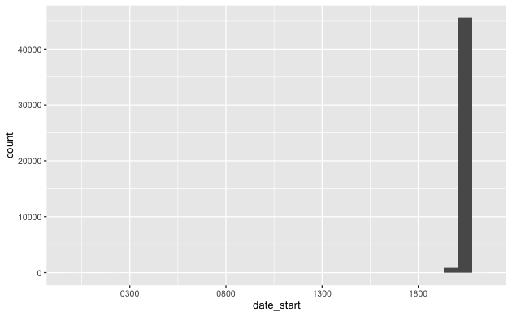

```r
trips %>%
  ggplot(aes(x = date_start)) +
  geom_histogram()
```

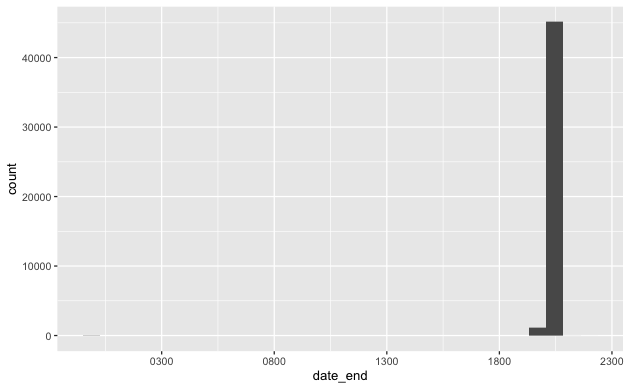

```r
trips %>%
  ggplot(aes(x = date_end)) +
  geom_histogram()
```

There are many ways to deal with outliers. To make it simple:

1: We could filter by some minimum / maximum date set manually 2: We could just delete extreme values using `percentage_rank` (deleting the 1 percent of obs with highest/lowest values). We will demonstrate this here:

```r
trips %<>%
  mutate(date_start_pct = date_start %>% as.numeric() %>% percent_rank(),
         date_end_pct = date_end %>% as.numeric() %>% percent_rank()) %>%
  filter(date_start_pct >= 0.01 & date_start_pct <= 0.99) %>%
  filter(date_end_pct >= 0.01 & date_end_pct <= 0.99)
```

Lets check how it looks now:

```r
trips %>%
  select(trip_duration, date_start, date_end) %>%
  summary()
```

```
 trip_duration       date_start            date_end
 Length:45176      Min.   :2002-09-11   Min.   :2003-06-08
 Class :difftime   1st Qu.:2015-09-08   1st Qu.:2015-10-10
 Mode  :numeric    Median :2016-09-20   Median :2016-10-14
                   Mean   :2016-03-09   Mean   :2016-04-10
                   3rd Qu.:2017-08-16   3rd Qu.:2017-09-06
                   Max.   :2018-09-01   Max.   :2018-10-12
```

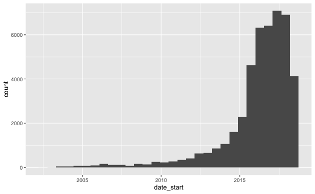

```r
trips %>%
  ggplot(aes(x = date_start)) +
  geom_histogram()
```

```r
trips %>%
  ggplot(aes(x = date_end)) +
  geom_histogram()
```

[output not shown]

Way more realistic, right?

## d. Join the countrylist data to the trips data-frame using the countrycode as a key

A simple left join.Be only aware of the different variable names

```r
trips %<>%
  left_join(countries, by = c("country_code" = "alpha_2"))
```

```r
trips %>% head()
```

| X1 | username | country | country_code | country_slug | date_end | date_start | latitude | longitude | place | place_slug | trip_duration | date_start_pct | date_end_pct | region | sub_region |
| --- | --- | --- | --- | --- | --- | --- | --- | --- | --- | --- | --- | --- | --- | --- | --- |
| 0 | @lewellenmichael | Mexico | MX | mexico | 2018-06-15 | 2018-06-04 | 21 | -101 | Guanajuato | mexico | 11 days | 0.9569201 | 0.9515976 | Americas | Latin America and the Caribbean |
| 1 | @lewellenmichael | Mexico | MX | mexico | 2018-06-03 | 2018-05-31 | 19 | -99 | Mexico City | mexico-city-mexico | 3 days | 0.9541456 | 0.9441062 | Americas | Latin America and the Caribbean |
| 2 | @lewellenmichael | Mexico | MX | mexico | 2017-11-05 | 2017-11-01 | 21 | -86 | Cancun | cancun-mexico | 4 days | 0.8031186 | 0.7909758 | Americas | Latin America and the Caribbean |
| 3 | @lewellenmichael | Jordan | JO | jordan | 2017-08-07 | 2017-07-24 | 31 | 35 | Amman | amman-jordan | 14 days | 0.7244650 | 0.7200777 | Asia | Western Asia |
| 4 | @waylandchin | China | CN | china | 2017-03-18 | 2017-02-17 | 40 | 122 | Yingkou | china | 29 days | 0.6033337 | 0.6090242 | Asia | Eastern Asia |
| 5 | @waylandchin | Vietnam | VN | vietnam | 2017-02-16 | 2016-09-02 | 10 | 106 | Ho Chi Minh City | ho-chi-minh-city-vietnam | 167 days | 0.4848908 | 0.5862047 | Asia | South-eastern Asia |

New variables are in, seems to work. Lets check if there are some trips that could not match:

```r
trips %>% filter(is.na(region) | is.na(sub_region))
```

| X1 | username | country | country_code | country_slug | date_end | date_start | latitude | longitude | place | place_slug | trip_duration | date_start_pct | date_end_pct | region | sub_region |
| --- | --- | --- | --- | --- | --- | --- | --- | --- | --- | --- | --- | --- | --- | --- | --- |
| 31 | @paulbremer | United Kingdom | UK | united-kingdom | 2018-06-26 | 2018-06-24 | 55 | -4 | Glasgow | glasgow-united-kingdom | 2 days | 0.96870631 | 0.95833333 | NA | NA |
| 32 | @paulbremer | United Kingdom | UK | united-kingdom | 2018-06-24 | 2018-06-22 | 57 | -5 | Armadale | united-kingdom | 2 days | 0.96750188 | 0.95695164 | NA | NA |
| 33 | @paulbremer | United Kingdom | UK | united-kingdom | 2018-06-22 | 2018-06-21 | 57 | -4 | Fort Augustus | united-kingdom | 1 days | 0.96685665 | 0.95591537 | NA | NA |
| 34 | @paulbremer | United Kingdom | UK | united-kingdom | 2018-06-21 | 2018-06-19 | 56 | -5 | Fort William | united-kingdom | 2 days | 0.96597484 | 0.95520294 | NA | NA |
| 35 | @paulbremer | United Kingdom | UK | united-kingdom | 2018-06-19 | 2018-06-17 | 55 | -3 | Edinburgh | edinburgh-united-kingdom | 2 days | 0.96481342 | 0.95414508 | NA | NA |
| 85 | @jezfx | United Kingdom | UK | united-kingdom | 2016-07-29 | 2016-07-05 | 53 | -2 | Manchester | manchester-united-kingdom | 24 days | 0.44862888 | 0.44712867 | NA | NA |
| 291 | @travelingpm | United Kingdom | UK | united-kingdom | 2010-10-23 | 2010-10-16 | 55 | -3 | Edinburgh | edinburgh-united-kingdom | 7 days | 0.04888698 | 0.04611399 | NA | NA |
| 293 | @travelingpm | United Kingdom | UK | united-kingdom | 2010-10-13 | 2010-10-10 | 51 | 0 | London | london-united-kingdom | 3 days | 0.04860738 | 0.04581174 | NA | NA |
| 313 | @cartogram | United Kingdom | UK | united-kingdom | 2017-11-15 | 2017-11-09 | 51 | 0 | London | london-united-kingdom | 6 days | 0.80963544 | 0.79818653 | NA | NA |
| 317 | @cartogram | United Kingdom | UK | united-kingdom | 2017-06-18 | 2017-05-12 | 55 | -4 | Glasgow | glasgow-united-kingdom | 37 days | 0.66800731 | 0.68162781 | NA | NA |

[output cut: 990 more lines]

```r
trips %>% filter(is.na(region) | is.na(sub_region)) %>%
  count(country_code, sort = TRUE)
```

[output not shown]

Ok, we see some country codes did not match. We dont bother for most small numbers, but one thing we might take a look at: UK did not match, since it is coded GB in the countries dataframe (Just inspect it). Lets delete the newly matched variables and start over again.

```r
trips %<>%
  select(-region, -sub_region)
```

Lets replace UK with GB

```r
trips %<>%
  mutate(country_code = country_code %>% str_replace(pattern = 'UK', replacement = 'GB'))
```

```r
trips %>%
  filter(country_code == 'UK' |country_code == 'GB') %>%
  count(country_code)
```

| country_code | n |
| --- | --- |
| GB | 1994 |

Ok, no more UK present… lets join again.

```r
trips %<>%
  left_join(countries, by = c("country_code" = "alpha_2"))
```

```r
trips %>% filter(is.na(region) | is.na(sub_region)) %>%
  count(country_code, sort = TRUE)
```

| country_code | n |
| --- | --- |
| IA | 15 |
| AA | 13 |
| CB | 12 |
| VB | 6 |
| KS | 4 |
| CT | 1 |
| OI | 1 |

Ok, the rest seems negligible… we just delete these observations…

```r
trips %<>%
  drop_na(region)
```

# 2: People

```r
people %>% glimpse()
```

```
Rows: 4,016
Columns: 6
$ X1            <dbl> 0, 1, 2, 3, 4, 5, 6, 7, 8, 9, 10, 11, 12, 13, 14, 15, 16, 17, 18, 19, 20, 21, 22, 23, 24, 25, 26, 27, 28, 29, 30, 31, 32, 33…
$ username      <chr> "@lewellenmichael", "@waylandchin", "@karan", "@skaboss217", "@apwn", "@samcalma", "@paulbremer", "@jtompl", "@jezfx", "@mar…
$ followers     <dbl> 1, 0, 2, 0, 17, 3, 4, 2, 17, 2, 11, 11, 5, 8, 0, 9, 3, 5, 25, 1, 1, 1, 61, 2, 11, 0, 1, 2, 93, 3, 2, 6, 9, 14, 27, 0, 9, 0, …
$ following     <dbl> 2, 2, 1, 1, 426, 3, 9, 3, 23, 2, 17, 6, 9, 7, 1, 6, 3, 34, 23, 4, 4, 4, 120, 2, 10, 2, 2, 5, 10, 4, 2, 1, 16, 14, 33, 1, 14,…
$ work_raw      <chr> "Software Dev, Startup Founder, Finance, Crypto, Product Manager, Education, Data, Ecommerce", NA, NA, NA, "Web Dev", NA, NA…
$ education_raw <chr> "High School, Bachelor's Degree", NA, NA, NA, NA, NA, NA, "High School, Bachelor's Degree, Master's Degree", NA, NA, NA, NA,…
```

## a: How many people have a least a “High School” diploma?

Lets see what educations we have in the data

```r
people %>% count(education_raw)
```

| education_raw | n |
| --- | --- |
| Bachelor's Degree | 197 |
| Bachelor's Degree, Master's Degree | 9 |
| High School | 58 |
| High School, Bachelor's Degree | 43 |
| High School, Bachelor's Degree, Master's Degree | 29 |
| Master's Degree | 115 |
| NA | 3565 |

Ok, that seems easy. Since all educations include Highschool (or higher), we can just assume that everybody that has all people with a non-missing education field have at least a highschool degree.

```r
sum(!is.na(people$education_raw))
```

```
[1] 451
```

However, for the rest we just dont know…

## b. How many “Startup Founders” have attained a “Master’s Degree”?

```r
people %>% count(work_raw, sort = TRUE)
```

| work_raw | n |
| --- | --- |
| NA | 2434 |
| Startup Founder | 326 |
| Software Dev | 98 |
| Marketing | 68 |
| Web Dev | 68 |
| Startup Founder, Marketing | 48 |
| UI/UX Design | 41 |
| Web Dev, Software Dev | 36 |
| Mobile Dev | 32 |
| Blogging | 23 |

[output cut: 487 more lines]

We cannot just filter for the string, since it is contained in multiple categories. We have to instead detect all strings where “Spartup Founder” appears. HEre we need the `stringr` package.

```r
people %>%
  filter(work_raw %>% str_detect('Startup Founder')) %>% head()
```

| X1 | username | followers | following | work_raw | education_raw |
| --- | --- | --- | --- | --- | --- |
| 0 | @lewellenmichael | 1 | 2 | Software Dev, Startup Founder, Finance, Crypto, Product Manager, Education, Data, Ecommerce | High School, Bachelor's Degree |
| 7 | @jtompl | 2 | 3 | Web Dev, Software Dev, Startup Founder, Product Manager, Education, Politics, Creative, SaaS | High School, Bachelor's Degree, Master's Degree |
| 10 | @ndbroadbent | 11 | 17 | Software Dev, Startup Founder | NA |
| 15 | @anigupta | 9 | 6 | Web Dev, Software Dev, Startup Founder, Product Manager | High School, Bachelor's Degree |
| 16 | @adventureinmyveins | 3 | 3 | Web Dev, Startup Founder | High School, Bachelor's Degree |
| 17 | @ayoungh | 5 | 34 | Startup Founder | NA |

```r
people %>%
  filter(education_raw %>% str_detect('Master\'s Degree')) %>% head()
```

| X1 | username | followers | following | work_raw | education_raw |
| --- | --- | --- | --- | --- | --- |
| 7 | @jtompl | 2 | 3 | Web Dev, Software Dev, Startup Founder, Product Manager, Education, Politics, Creative, SaaS | High School, Bachelor's Degree, Master's Degree |
| 14 | @jaszczakw | 0 | 1 | Web Dev, Software Dev | Master's Degree |
| 23 | @voising | 2 | 2 | Web Dev, Software Dev | Master's Degree |
| 57 | @aaleksandar | 7 | 5 | Web Dev, Startup Founder, Product Manager, Journalism, Data, Community, Architecture | Master's Degree |
| 89 | @moraveklukas | 1 | 10 | Web Dev, UI/UX Design, Startup Founder, Product Manager, Data, Marketing, Sales, Ecommerce, SaaS | Master's Degree |
| 102 | @rockyrohde | 2 | 11 | Education, Community | Master's Degree |

Putting it together and counting

```r
people %>%
  filter(work_raw %>% str_detect('Startup Founder') & education_raw %>% str_detect('Master\'s Degree') ) %>%
  summarise(n = n())
```

| n |
| --- |
| 53 |

```r
NA
```

Its 53…

# 3. Trips

```r
trips %>% glimpse()
```

```
Rows: 45,124
Columns: 16
$ X1             <dbl> 0, 1, 2, 3, 4, 5, 6, 7, 8, 9, 10, 11, 12, 13, 14, 15, 16, 17, 18, 19, 20, 21, 22, 23, 24, 25, 26, 27, 28, 29, 30, 31, 32, 3…
$ username       <chr> "@lewellenmichael", "@lewellenmichael", "@lewellenmichael", "@lewellenmichael", "@waylandchin", "@waylandchin", "@waylandch…
$ country        <chr> "Mexico", "Mexico", "Mexico", "Jordan", "China", "Vietnam", "Hong Kong", "China", "China", "China", "Thailand", "Malaysia",…
$ country_code   <chr> "MX", "MX", "MX", "JO", "CN", "VN", "HK", "CN", "CN", "CN", "TH", "MY", "KH", "VN", "IN", "IN", "IN", "IN", "IN", "IN", "IN…
$ country_slug   <chr> "mexico", "mexico", "mexico", "jordan", "china", "vietnam", "hong-kong", "china", "china", "china", "thailand", "malaysia",…
$ date_end       <date> 2018-06-15, 2018-06-03, 2017-11-05, 2017-08-07, 2017-03-18, 2017-02-16, 2016-09-01, 2016-08-02, 2016-07-31, 2016-07-03, 20…
$ date_start     <date> 2018-06-04, 2018-05-31, 2017-11-01, 2017-07-24, 2017-02-17, 2016-09-02, 2016-08-02, 2016-07-31, 2016-07-03, 2016-06-03, 20…
$ latitude       <dbl> 21, 19, 21, 31, 40, 10, 22, 22, 22, 18, 7, 3, 11, 10, 13, 26, 27, 27, 28, 28, 19, 11, 22, 22, 38, 43, 45, 42, 25, 1, 34, 55…
$ longitude      <dbl> -101, -99, -86, 35, 122, 106, 114, 114, 113, 109, 98, 101, 104, 106, 80, 75, 78, 78, 77, 77, 72, 79, 114, 114, -77, -89, -6…
$ place          <chr> "Guanajuato", "Mexico City", "Cancun", "Amman", "Yingkou", "Ho Chi Minh City", "Shenzhen", "Hong Kong", "Zhuhai", "Sanya", …
$ place_slug     <chr> "mexico", "mexico-city-mexico", "cancun-mexico", "amman-jordan", "china", "ho-chi-minh-city-vietnam", "hong-kong", "hong-ko…
$ trip_duration  <drtn> 11 days, 3 days, 4 days, 14 days, 29 days, 167 days, 30 days, 2 days, 28 days, 30 days, 12 days, 33 days, 60 days, 92 days…
$ date_start_pct <dbl> 0.95692010, 0.95414561, 0.80311861, 0.72446500, 0.60333369, 0.48489085, 0.46589956, 0.46402839, 0.44695129, 0.42716421, 0.4…
$ date_end_pct   <dbl> 0.9515976, 0.9441062, 0.7909758, 0.7200777, 0.6090242, 0.5862047, 0.4690415, 0.4508636, 0.4485967, 0.4315415, 0.4113774, 0.…
$ region         <chr> "Americas", "Americas", "Americas", "Asia", "Asia", "Asia", "Asia", "Asia", "Asia", "Asia", "Asia", "Asia", "Asia", "Asia",…
$ sub_region     <chr> "Latin America and the Caribbean", "Latin America and the Caribbean", "Latin America and the Caribbean", "Western Asia", "E…
```

## a. Which country received the highest number of trips? – And which the lowest?

Thats easy…

```r
trips %>%
  count(country_code) %>%
  arrange(desc(n)) %>%
  head()
```

| country_code | n |
| --- | --- |
| US | 7331 |
| TH | 3308 |
| GB | 1994 |
| DE | 1941 |
| ES | 1910 |
| FR | 1461 |

The US recieves the most trips.

```r
trips %>%
  count(country_code) %>%
  arrange(n) %>%
  head()
```

| country_code | n |
| --- | --- |
| DJ | 1 |
| DZ | 1 |
| GN | 1 |
| MQ | 1 |
| NC | 1 |
| PS | 1 |

## b. Which region received the highest number of trips in 2017? Use the start of trips as a time reference.

Since the dates are already datetimes, we can just extract the year with the year() function of lubridate.

```r
trips %>%
  filter(year(date_start) == 2017) %>%
  count(country_code, sort = TRUE)
```

| country_code | n |
| --- | --- |
| US | 1879 |
| TH | 906 |
| ES | 613 |
| GB | 550 |
| DE | 485 |
| FR | 404 |
| ID | 377 |
| VN | 363 |
| MX | 322 |
| PT | 313 |

[output cut: 134 more lines]

Its again the US.

## c. Which country in “Western Europe” did travelers spent least time? – Provide visualization

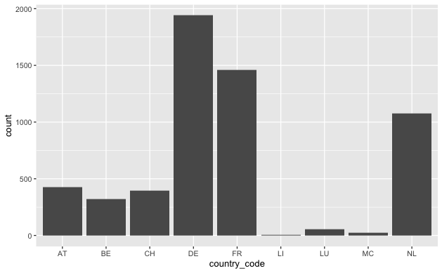

```r
trips %>%
  filter(sub_region == 'Western Europe') %>%
#  count(country_code, sort = TRUE) %>%
  ggplot(aes(x = country_code)) +
  geom_bar()
```

Could be done pettier, though

## d. Do nomad Startup Founders tend to have shorter or longer trips on average?

Here, we first need to do a join…

## e. visualize over-time median trip duration overall (bonus: and split by world-region) The plot will

look weird ^^.